# Streaming Spotify TOP 100

Ditya Anggraheni Rahayu

1/21/2022

## Latar Belakang Dataset

Spotify adalah salah satu platform untuk streaming musik dan podcast. Di notebook ini, saya akan melakukan analisis lagu-lagu streaming Spotify top 100 untuk menemukan pola yang menarik di antara lagu-lagu top tersebut.

## Import Library

```r
library(tidyverse)
library(skimr)
library(DataExplorer)
library(readr)
library(data.table)
library(Hmisc)
```

## Mengakses dataset

```r
df <- read.csv("D:/KULIAH/Sem 5/PSDS/Top 100 most Streamed.csv")
head(df, n = 5)
```

```
##                    title        artist                 top.genre year
## 1        Blinding Lights    The Weeknd canadian contemporary r&b 2020
## 2       Watermelon Sugar  Harry Styles                       pop 2019
## 3 Mood (feat. iann dior)      24kGoldn                  cali rap 2021
## 4      Someone You Loved Lewis Capaldi                       pop 2019
## 5                Perfect    Ed Sheeran                       pop 2017
##   beats.per.minute energy danceability loudness.dB liveness valance length
## 1              171     73           51          -6        9      33    200
## 2               95     82           55          -4       34      56    174
## 3               91     72           70          -4       32      73    141
## 4              110     41           50          -6       11      45    182
## 5               95     45           60          -6       11      17    263
##   acousticness speechiness popularity
## 1            0           6         91
## 2           12           5         88
## 3           17           4         88
## 4           75           3         86
## 5           16           2         86
```

## Memahami dataset

Variabel-variabel yang terdapat pada dataset ini adalah sebagai berikut:

1. Title = judul lagu
2. Artist = penyanyi
3. Top genre = genre lagu
4. Year = tahun dirilis
5. Beats per minute = jumlah beat/ketukan dalam satu menit
6. Energy = kemampuan suatu musik untuk meningkatkan emosi pendengarnya
7. Danceability = kecocokan dalam sebuah trek musik untuk menari berdarkan unsur musik
8. Loudness = keseluruhan kenyaringan suatu lagu dalam desibel(dB)
9. Liveness = Mendeteksi keberadaan audiens dalam rekaman
10. Valance = indikasi jenis emosi
11. Length = durasi lagu
12. Acousticness = ukuran kepercayaan yang menunjukan apakah trek tersebut akustik
13. Speechiness = mendeteksi kehadiran kata-kata yang diucapkan dalam sebuah trek pada musik
14. Popularity = tingkat popularitas lagu

## Pertanyaan Analisis

1. Banyak lagu yang dimiliki artis pada top 100
2. Lagu Terpopuler Berdasarkan Tahun rilis
3. Genre Paling mendominasi di Top 100
4. Lagu Dengan durasi terlama berdasarkan genre

## Exploratory Data Analysis - EDA

### Dimensi data

```r
dim(df)
```

```
## [1] 100  14
```

Artinya kita memiliki data dengan 14 kolom dan 100 baris

### Variabel pada dataset

```r
names(df) #variabel
```

```
##  [1] "title"            "artist"           "top.genre"        "year"
##  [5] "beats.per.minute" "energy"           "danceability"     "loudness.dB"
##  [9] "liveness"         "valance"          "length"           "acousticness"
## [13] "speechiness"      "popularity"
```

```r
str(df)   #struktur dataset
```

```
## 'data.frame':    100 obs. of  14 variables:
##  $ title           : Factor w/ 100 levels "7 rings","7 Years",..: 8 93 51 72 57 6 48 15 70 50 ...
##  $ artist          : Factor w/ 64 levels "24kGoldn","5 Seconds of Summer",..: 58 21 1 33 17 23 7 49 17 42 ...
##  $ top.genre       : Factor w/ 34 levels "acoustic pop",..: 9 31 8 31 31 28 20 18 31 31 ...
##  $ year            : int  2020 2019 2021 2019 2017 2017 2018 2019 2017 2021 ...
##  $ beats.per.minute: int  171 95 91 110 95 125 115 120 96 91 ...
##  $ energy          : int  73 82 72 41 45 78 30 76 65 33 ...
##  $ danceability    : int  51 55 70 50 60 78 35 70 83 78 ...
##  $ loudness.dB     : int  -6 -4 -4 -6 -6 -4 -10 -3 -3 -7 ...
##  $ liveness        : int  9 34 32 11 11 8 10 9 9 8 ...
##  $ valance         : int  33 56 73 45 17 67 12 55 93 60 ...
##  $ length          : int  200 174 141 182 263 204 200 215 234 189 ...
##  $ acousticness    : int  0 12 17 75 16 6 93 19 58 84 ...
##  $ speechiness     : int  6 5 4 3 2 13 3 4 8 6 ...
##  $ popularity      : int  91 88 88 86 86 86 86 86 85 85 ...
```

Kita dapat mengetahui tipe-tipe data masing-masing variabel dan nama-nama variabel dalam dataset. Terdapat dua buah jenis data pada dataset tersebut yaitu: factor (title, artist, dan top genre) Integer (year, beats per minute, energy, dancebility, loudness, liveness, valance, length, accousticness, speechiness, dan popularity)

### Ringkasan data

```r
skim(df)
```

Data summary

| Name | df |
| --- | --- |
| Number of rows | 100 |
| Number of columns | 14 |
| _______________________ |  |
| Column type frequency: |  |
| factor | 3 |
| numeric | 11 |
| ________________________ |  |
| Group variables | None |

**Variable type: factor**

| skim_variable | n_missing | complete_rate | ordered | n_unique | top_counts |
| --- | --- | --- | --- | --- | --- |
| title | 0 | 1 | FALSE | 100 | 7 r: 1, 7 Y: 1, All: 1, Att: 1 |
| artist | 0 | 1 | FALSE | 64 | Pos: 7, Ed : 5, Ima: 4, The: 4 |
| top.genre | 0 | 1 | FALSE | 34 | dan: 28, pop: 11, dfw: 7, can: 6 |

**Variable type: numeric**

| skim_variable | n_missing | complete_rate | mean | sd | p0 | p25 | p50 | p75 | p100 | hist |
| --- | --- | --- | --- | --- | --- | --- | --- | --- | --- | --- |
| year | 0 | 1 | 2015.96 | 5.33 | 1975 | 2015.00 | 2017.0 | 2018.00 | 2021 | ▁▁▁▁▇ |
| beats.per.minute | 0 | 1 | 116.97 | 27.47 | 71 | 95.00 | 115.0 | 135.25 | 186 | ▆▇▇▃▂ |
| energy | 0 | 1 | 62.68 | 16.49 | 11 | 52.00 | 64.5 | 76.00 | 92 | ▁▃▇▇▆ |
| danceability | 0 | 1 | 66.96 | 13.60 | 35 | 59.00 | 69.0 | 77.00 | 91 | ▂▂▅▇▃ |
| loudness.dB | 0 | 1 | -6.10 | 1.99 | -14 | -7.00 | -6.0 | -5.00 | -3 | ▁▁▂▇▇ |
| liveness | 0 | 1 | 16.86 | 12.97 | 3 | 10.00 | 12.0 | 17.25 | 79 | ▇▁▁▁▁ |
| valance | 0 | 1 | 49.97 | 21.74 | 6 | 33.75 | 48.0 | 66.00 | 93 | ▃▅▇▆▃ |
| length | 0 | 1 | 214.53 | 35.93 | 119 | 190.50 | 210.0 | 234.25 | 354 | ▁▇▆▁▁ |
| acousticness | 0 | 1 | 24.95 | 26.28 | 0 | 4.00 | 13.0 | 41.50 | 98 | ▇▂▂▂▁ |
| speechiness | 0 | 1 | 9.93 | 9.42 | 2 | 4.00 | 6.0 | 11.00 | 46 | ▇▂▁▁▁ |
| popularity | 0 | 1 | 79.67 | 5.91 | 53 | 79.00 | 81.0 | 83.00 | 91 | ▁▁▁▇▂ |

### Deskripsi data

```r
describe(df)
```

```
## df
##
##  14  Variables      100  Observations
## --------------------------------------------------------------------------------
## title
##        n  missing distinct
##      100        0      100
##
## lowest : 7 rings                      7 Years                      All of Me                    Attention                    bad guy
## highest: when the party's over        Without Me (with Juice WRLD) Wonderwall - Remastered      XO Tour Llif3                Youngblood
## --------------------------------------------------------------------------------
## artist
##        n  missing distinct
##      100        0       64
##
## lowest : 24kGoldn            5 Seconds of Summer Alan Walker         Ariana Grande       Avicii
## highest: Travis Scott        Twenty One Pilots   Vance Joy           Wiz Khalifa         XXXTENTACION
## --------------------------------------------------------------------------------
## top.genre
##        n  missing distinct
##      100        0       34
##
## lowest : acoustic pop           alternative rock       australian dance       australian pop         beatlesque
## highest: north carolina hip hop pop                    pop dance              pop rap                rap
## --------------------------------------------------------------------------------
## year
##        n  missing distinct     Info     Mean      Gmd      .05      .10
##      100        0       14     0.98     2016    3.854     2012     2013
##      .25      .50      .75      .90      .95
##     2015     2017     2018     2019     2020
##
## lowest : 1975 1995 2004 2008 2012, highest: 2017 2018 2019 2020 2021
##
## Value      1975 1995 2004 2008 2012 2013 2014 2015 2016 2017 2018 2019 2020
## Frequency     1    1    1    1    3    4    6   13   16   12   20   16    3
## Proportion 0.01 0.01 0.01 0.01 0.03 0.04 0.06 0.13 0.16 0.12 0.20 0.16 0.03
##
## Value      2021
## Frequency     3
## Proportion 0.03
```

[output cut: 70 more lines]

```
##        n  missing distinct     Info     Mean      Gmd      .05      .10
##      100        0       31    0.989     9.93    8.854     3.00     3.00
##      .25      .50      .75      .90      .95
##     4.00     6.00    11.00    24.10    32.05
##
## lowest :  2  3  4  5  6, highest: 33 34 38 44 46
## --------------------------------------------------------------------------------
## popularity
##        n  missing distinct     Info     Mean      Gmd      .05      .10
##      100        0       22    0.989    79.67    5.715    66.95    72.00
##      .25      .50      .75      .90      .95
##    79.00    81.00    83.00    84.10    86.00
##
## lowest : 53 56 66 67 70, highest: 84 85 86 88 91
## --------------------------------------------------------------------------------
```

### Mengecek missing data

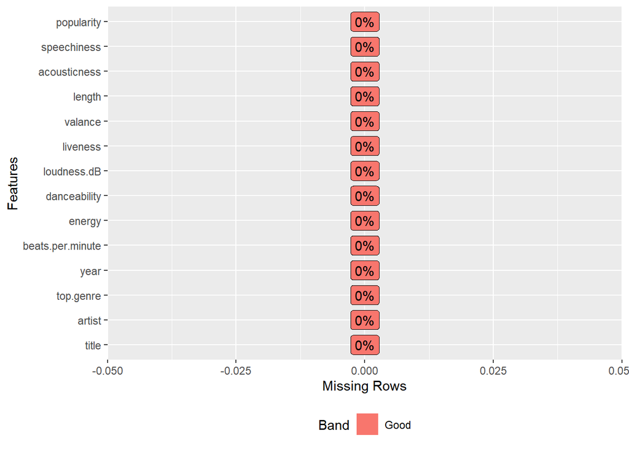

```r
plot_missing(df)
```

Hasil visualisasi dari fungsi *plot missing* pada dataset, terlihat bahwa tidak terdapat missing value pada setiap kolomnya.

### Mengecek Outlier

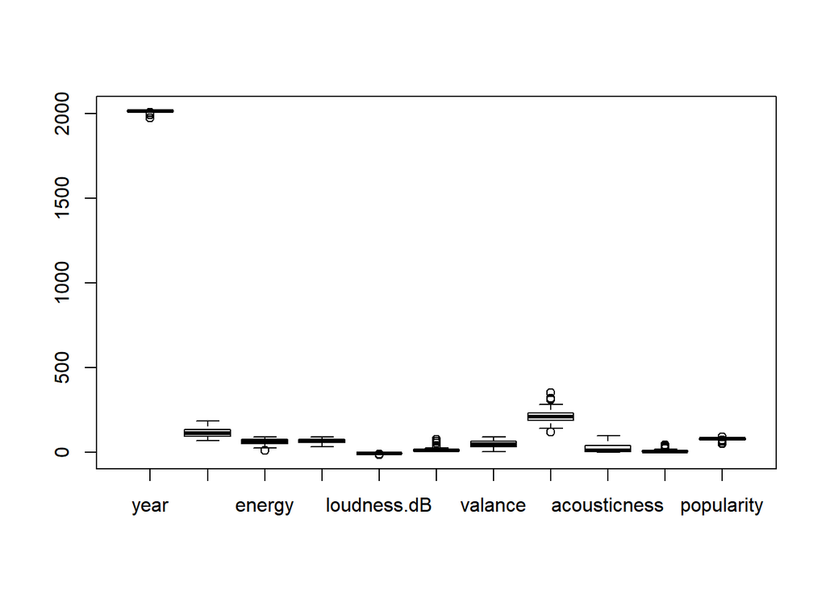

```r
num_cols <- unlist(lapply(df, is.numeric)) #Memilih kolom bertipe numerik
df_num <- df[,num_cols]
boxplot(df_num)
```

### Melihat Korelasi Data

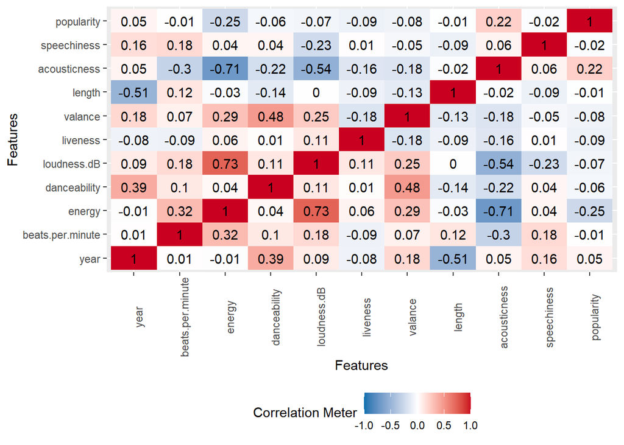

```r
plot_correlation(df_num)
```

### Plot Distribusi Data Numerik

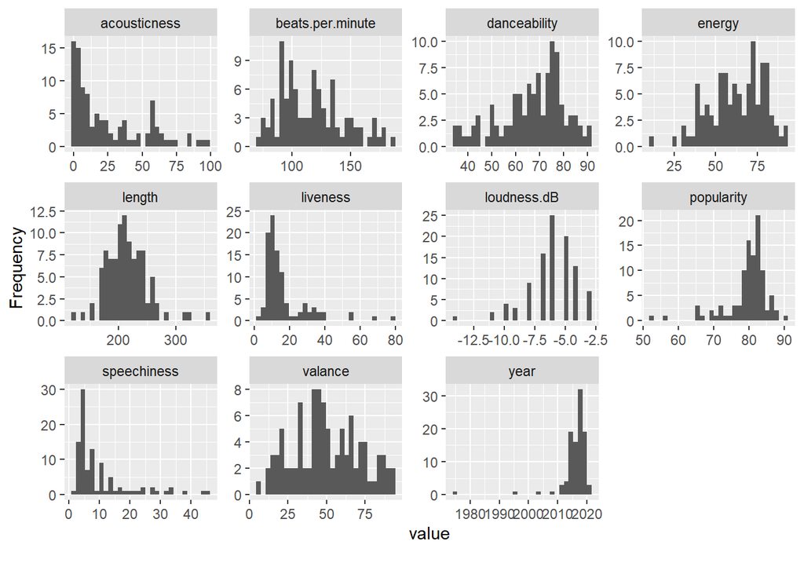

```r
plot_histogram(df)
```

### Plot Distribusi Data Kategorikal

```
## 2 columns ignored with more than 50 categories.
## title: 100 categories
## artist: 64 categories
```

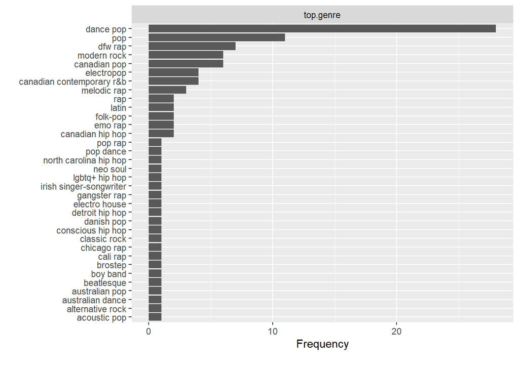

```r
plot_bar(df)
```

## Menjawab Pertanyaan

### 1. Banyak lagu yang dimiliki artis pada top 100

```r
nama <- df %>%
  group_by(artist) %>%
  dplyr::summarize(Total=n())
print(nama)
```

```
## # A tibble: 64 x 2
##    artist              Total
##    <fct>               <int>
##  1 24kGoldn                1
##  2 5 Seconds of Summer     1
##  3 Alan Walker             1
##  4 Ariana Grande           2
##  5 Avicii                  1
##  6 benny blanco            1
##  7 Billie Eilish           3
##  8 Bruno Mars              1
##  9 Calvin Harris           1
## 10 Camila Cabello          1
## # ... with 54 more rows
```

### 2. Lagu Terpopuler Berdasarkan Tahun rilis

```r
max <- df %>%
  group_by(year) %>%
  summarise(popularity = max(popularity))

df %>%
  right_join(max, by = c("year", "popularity")) %>%
  select(artist, title,year,popularity)
```

```
##                     artist                               title year popularity
## 1               The Weeknd                     Blinding Lights 2020         91
## 2             Harry Styles                    Watermelon Sugar 2019         88
## 3                 24kGoldn              Mood (feat. iann dior) 2021         88
## 4               Ed Sheeran                             Perfect 2017         86
## 5          Imagine Dragons                            Believer 2017         86
## 6            Billie Eilish                lovely (with Khalid) 2018         86
## 7         The Chainsmokers                              Closer 2016         84
## 8             James Arthur                Say You Won't Let Go 2016         84
## 9              John Legend                           All of Me 2013         84
## 10            Travis Scott                          goosebumps 2016         84
## 11                  Avicii                          Wake Me Up 2013         84
## 12              Ed Sheeran                          Photograph 2014         83
## 13       Twenty One Pilots                        Stressed Out 2015         83
## 14              The Weeknd                           The Hills 2015         83
## 15 Macklemore & Ryan Lewis    Can't Hold Us - feat. Ray Dalton 2012         82
## 16                   Queen Bohemian Rhapsody - Remastered 2011 1975         81
## 17             The Killers                      Mr. Brightside 2004         81
## 18              Jason Mraz                           I'm Yours 2008         80
## 19                   Oasis             Wonderwall - Remastered 1995         77
```

### 3. Genre Paling mendominasi di Top 100

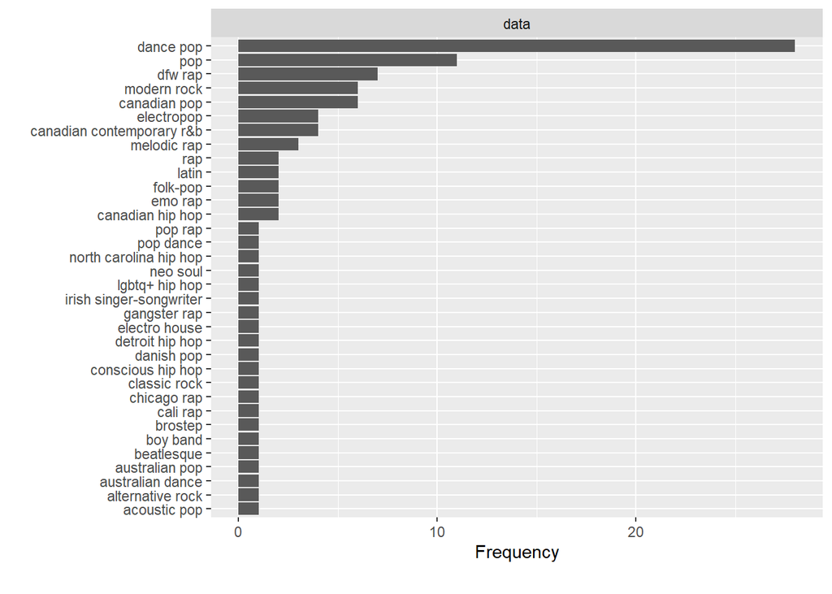

```r
plot_bar(df$top.genre)
```

Genre Paling mendominasi di Top 100 adalah dance pop

### 4. Lagu Dengan durasi terlama berdasarkan genre

```r
durasi <- df %>%
  group_by(top.genre) %>%
  summarise(length = max(length))

df %>%
  right_join(durasi, by = c("top.genre", "length")) %>%
  select(artist,title,top.genre, length)
```

```
##                     artist                               title
## 1                 24kGoldn              Mood (feat. iann dior)
## 2          Imagine Dragons                            Believer
## 3            Billie Eilish                lovely (with Khalid)
## 4               Juice WRLD                        Lucid Dreams
## 5              John Legend                           All of Me
## 6                   DaBaby        ROCKSTAR (feat. Roddy Ricch)
## 7             XXXTENTACION                                SAD!
## 8             Travis Scott                          SICKO MODE
## 9              Roddy Ricch                             The Box
## 10              The Weeknd                           The Hills
## 11              Ed Sheeran                   Thinking out Loud
## 12           Justin Bieber                       Love Yourself
## 13                  Hozier                   Take Me To Church
## 14              Marshmello                             Happier
```

[output cut: 55 more lines]